# GLM para dados categóricos

Layla Paiva

## 1 Modelo Linear Generalizado para Dados Categóricos

Dados Categóricos são aqueles que se apresentam sem valor numérico. São dados de classificação em grupos ou categorias.

## 2 Na prática

Vamos entender como utilizar o GLM para dados categóricos na prática

```r
# 1. Importando o banco de dados
dados <- readRDS("~/Disciplinas do Mestrado/ECL0072 - MODELOS LINEARES GENERALIZADOS E ADITIVOS PARA DADOS ECOLÓGICOS/ECL0072-GLM_GAM-gh-pages/ECL0072-GLM_GAM-gh-pages/Dados/palmerpenguins_extended.rds")

#Pacotes uilizados
library(VGAM) #Modelo multinomial
```

```r
library(nnet) #Modelo multinomial (pacote alternativo)
library(ggplot2)
library(dplyr)
library(DHARMa)
library(ggeffects) #para plotar os resultados
library(performance) #avaliação dos residuos
```

## 3 Análise Exploratória

Entendendo os dados e como estes se dispõem no arquivo.

```r
# Análise Exploratória
str(dados)
```

```
## 'data.frame':    3430 obs. of  11 variables:
##  $ species          : chr  "Adelie" "Adelie" "Adelie" "Adelie" ...
##  $ island           : chr  "Biscoe" "Biscoe" "Biscoe" "Biscoe" ...
##  $ bill_length_mm   : num  53.4 49.3 55.7 38 60.7 35.7 61 66.1 61.4 54.9 ...
##  $ bill_depth_mm    : num  17.8 18.1 16.6 15.6 17.9 16.8 20.8 20.8 19.9 22.3 ...
##  $ flipper_length_mm: num  219 245 226 221 177 194 211 246 270 230 ...
##  $ body_mass_g      : num  5687 6811 5388 6262 4811 ...
##  $ sex              : chr  "female" "female" "female" "female" ...
##  $ diet             : chr  "fish" "fish" "fish" "fish" ...
##  $ life_stage       : chr  "adult" "adult" "adult" "adult" ...
##  $ health_metrics   : chr  "overweight" "overweight" "overweight" "overweight" ...
##  $ year             : int  2021 2021 2021 2021 2021 2021 2021 2021 2021 2021 ...
```

```r
summary(dados)
```

```
##    species             island          bill_length_mm  bill_depth_mm
##  Length:3430        Length:3430        Min.   :13.60   Min.   : 9.10
##  Class :character   Class :character   1st Qu.:28.90   1st Qu.:16.60
##  Mode  :character   Mode  :character   Median :34.50   Median :18.40
##                                        Mean   :38.53   Mean   :18.45
##                                        3rd Qu.:46.60   3rd Qu.:20.30
##                                        Max.   :88.20   Max.   :27.90
##  flipper_length_mm  body_mass_g        sex                diet
##  Min.   :140       Min.   : 2477   Length:3430        Length:3430
##  1st Qu.:185       1st Qu.: 3844   Class :character   Class :character
##  Median :203       Median : 4634   Mode  :character   Mode  :character
##  Mean   :207       Mean   : 4835
##  3rd Qu.:226       3rd Qu.: 5622
##  Max.   :308       Max.   :10549
##   life_stage        health_metrics          year
##  Length:3430        Length:3430        Min.   :2021
##  Class :character   Class :character   1st Qu.:2022
##  Mode  :character   Mode  :character   Median :2024
##                                        Mean   :2023
##                                        3rd Qu.:2024
##                                        Max.   :2025
```

O arquivo possui 3.430 linhas de dados e 11 variáveis, incluindo informações sobre a espécie, local de ocorrência, medições e pesos corporais, sexo, dieta e métricas de saúde, etc.

A pergunta da análise será: a métrica de saúde dos pinguins é influenciada pelo estágio de vida, espécie e sexo desses animais?

Nesse sentido, a variável dependente (Y) será a métrica de saúde(acima, abaixo ou peso normal).

Já as variáveis independentes (X) serão: - Estágio de vida - Espécie - Sexo

Classificando as variáveis corretamente:

vou mudar a natureza de todas as variáveis para que sejam incluídas nas análises.

```r
#Convertendo a natureza das variáveis

cols <- c("species", "island", "sex", "diet", "life_stage", "health_metrics", "year")

dados[, cols] <- lapply(dados[, cols], factor)
```

Verificando a converção:

```r
str(dados)
```

```
## 'data.frame':    3430 obs. of  11 variables:
##  $ species          : Factor w/ 3 levels "Adelie","Chinstrap",..: 1 1 1 1 1 1 1 1 1 1 ...
##  $ island           : Factor w/ 3 levels "Biscoe","Dream",..: 1 1 1 1 1 1 1 1 1 1 ...
##  $ bill_length_mm   : num  53.4 49.3 55.7 38 60.7 35.7 61 66.1 61.4 54.9 ...
##  $ bill_depth_mm    : num  17.8 18.1 16.6 15.6 17.9 16.8 20.8 20.8 19.9 22.3 ...
##  $ flipper_length_mm: num  219 245 226 221 177 194 211 246 270 230 ...
##  $ body_mass_g      : num  5687 6811 5388 6262 4811 ...
##  $ sex              : Factor w/ 2 levels "female","male": 1 1 1 1 1 1 1 2 2 2 ...
##  $ diet             : Factor w/ 4 levels "fish","krill",..: 1 1 1 1 1 1 1 1 1 1 ...
##  $ life_stage       : Factor w/ 3 levels "adult","chick",..: 1 1 1 1 3 3 1 1 1 1 ...
##  $ health_metrics   : Factor w/ 3 levels "healthy","overweight",..: 2 2 2 2 2 2 2 2 2 2 ...
##  $ year             : Factor w/ 5 levels "2021","2022",..: 1 1 1 1 1 1 1 1 1 1 ...
```

### 3.1 Entendendo as variáveis

Vizualizando as possíveis relações:

Primeiramente a relação entre a espécie e a condição de saúde em relação ao peso

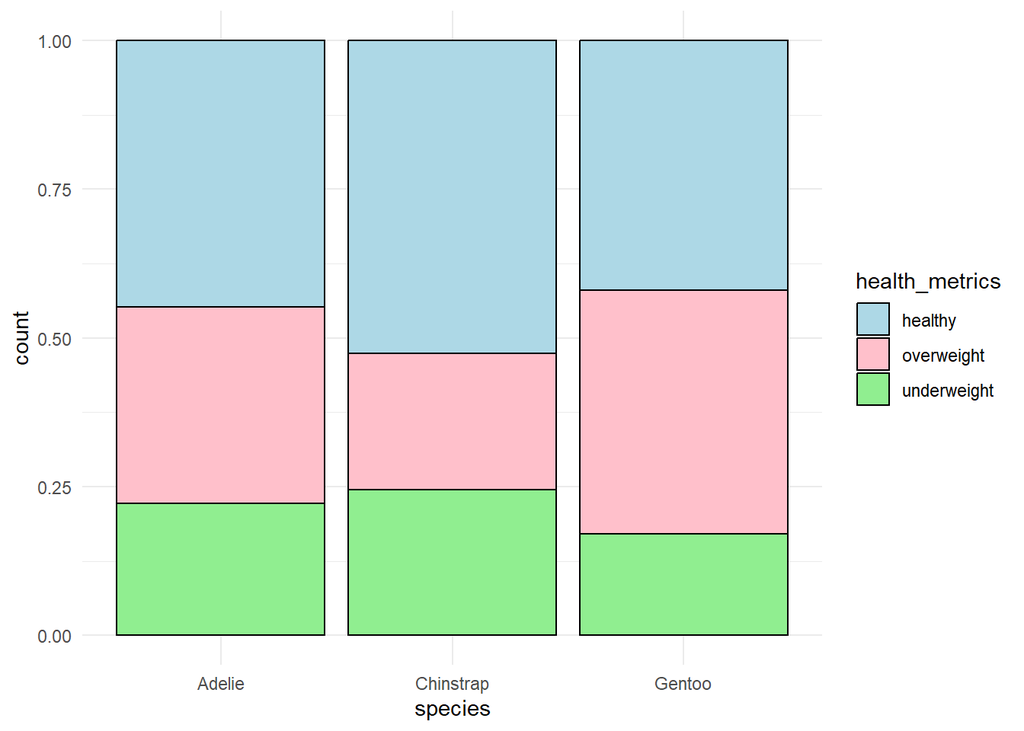

```r
ggplot(dados, aes(x = species, fill = health_metrics)) +
  geom_bar(position = "fill", color = "black") +
  scale_fill_manual(values = c("lightblue", "pink", "lightgreen"))+
  theme_minimal()
```

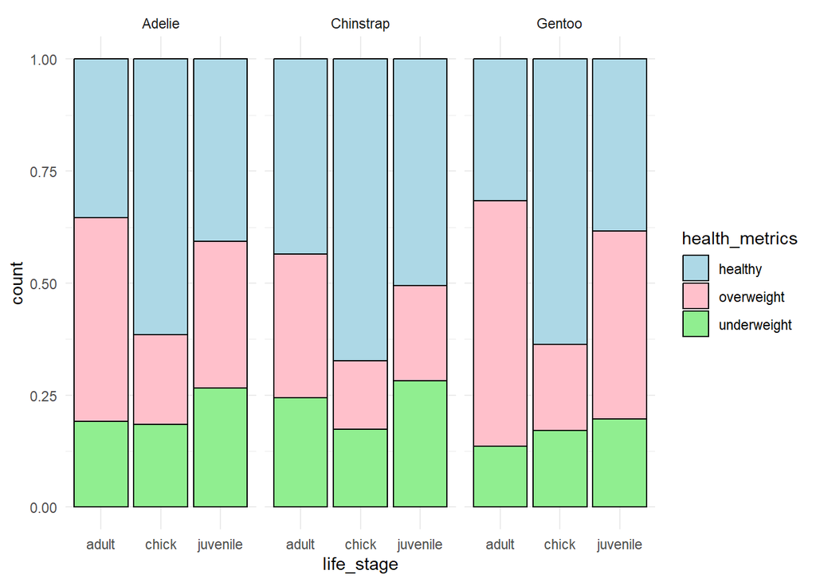

```r
#A relação entre o estágio de vida e a condição de saúde em relação ao peso
ggplot(dados, aes(x = life_stage, fill = health_metrics)) +
  geom_bar(position = "fill", color = "black") +
  scale_fill_manual(values = c("lightblue", "pink", "lightgreen"))+
  facet_wrap(species ~ .) +
  theme_minimal()
```

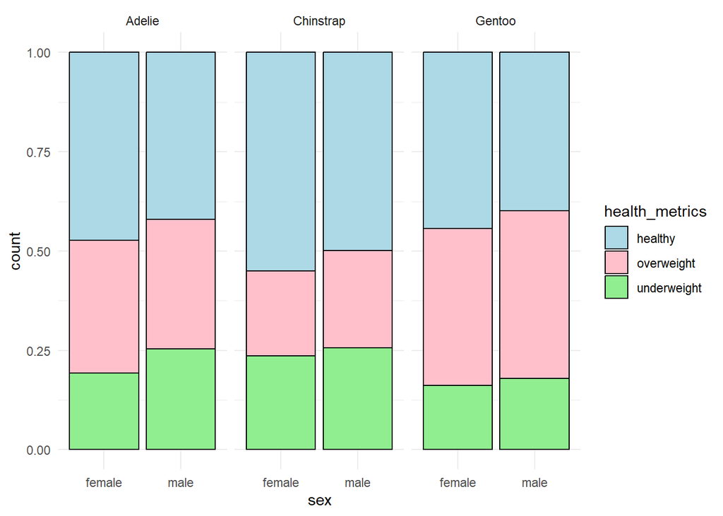

```r
#A relação entre o sexo e a condição de saúde em relação ao peso
ggplot(dados, aes(x = sex, fill = health_metrics)) +
geom_bar(position = "fill", color = "black") +
  scale_fill_manual(values = c("lightblue", "pink", "lightgreen"))+
  facet_wrap(species ~ .) +
  theme_minimal()
```

## Hipóteses

Com as análises iniciais, podemos formar nossas hipóteses!

- $H_1:$ A condição de saúde dos pinguis diferem entre as espécies
- $H_2:$ A condição de saúde dos pinguis diferem entre os estágios de vida
- $H_3:$ A condição de saúde dos pinguis diferem entre os sexos

Avaliar como fatores intrinsecos das espécies de pinguins pode afetar suas condições de saúde referentes ao peso.

1. **Avaliar se a condição do peso dos pinguins é influenciada pela espécie**
   - Permitirá determinar se a incidência de baixo peso ou sobrepeso difere entre as espécies.
2. **Avaliar se a condição do peso dos pinguins é influenciada pelo estágio de vida**
   - Permitirá determinar se a incidência de baixo peso ou sobrepeso difere entre os estágios de vida.
3. **Avaliar se a condição do peso dos pinguins é influenciada pelo sexo** - Permitirá determinar se a incidência de baixo peso ou sobrepeso difere entre fêmeas e machos.

## 4 Análises & Resultados

Definindo o nível de referência.

```r
levels(dados$health_metrics)
```

```
## [1] "healthy"     "overweight"  "underweight"
```

Iniciaremos as análises montando os modelos. Em seguida seram analisadas as predições e por fim, formados os gráficos de resultados!

Modelo 1

```r
#Avaliando a relação entre a condição de saúde e as espécies
modelo1 <- vglm(health_metrics ~ species,
                family = multinomial(refLevel = 1),  # define a categoria de referência
                data = dados)

summary(modelo1)
```

```
##
## Call:
## vglm(formula = health_metrics ~ species, family = multinomial(refLevel = 1),
##     data = dados)
##
## Coefficients:
##                    Estimate Std. Error z value Pr(>|z|)
## (Intercept):1      -0.30405    0.05809  -5.234 1.66e-07 ***
## (Intercept):2      -0.69889    0.06568 -10.640  < 2e-16 ***
## speciesChinstrap:1 -0.53313    0.11604  -4.594 4.34e-06 ***
## speciesChinstrap:2 -0.06368    0.11790  -0.540  0.58909
## speciesGentoo:1     0.27697    0.08511   3.254  0.00114 **
## speciesGentoo:2    -0.20131    0.10449  -1.927  0.05403 .
## ---
## Signif. codes:  0 '***' 0.001 '**' 0.01 '*' 0.05 '.' 0.1 ' ' 1
##
## Names of linear predictors: log(mu[,2]/mu[,1]), log(mu[,3]/mu[,1])
##
## Residual deviance: 7151.254 on 6854 degrees of freedom
##
## Log-likelihood: -3575.627 on 6854 degrees of freedom
##
## Number of Fisher scoring iterations: 4
##
## No Hauck-Donner effect found in any of the estimates
##
##
## Reference group is level  1  of the response
```

Predizendo…

```r
#Predições de probabilidade para cada espécie
dados_pred <- data.frame(species = levels(dados$species))

preds <- predict(modelo1,
                 newdata = dados_pred,
                 type = "response") %>% data.frame()

print(colnames(preds))
```

```
## [1] "healthy"     "overweight"  "underweight"
```

Formatar os resultados para gerar o gráfico

```r
preds$species <- dados_pred$species

colnames(preds) <- c("healthy", "overweight", "underweight","species") #Renomeando as colunas da espécie, assumindo a mesma ordem do modelo

#Transformar dado para o formato longo (necessário para o ggplot2)
preds11 <- preds %>%
                tidyr::pivot_longer(cols = c("healthy", "overweight", "underweight"),
                                    names_to = "health_metrics",
                                    values_to = "Probability")
```

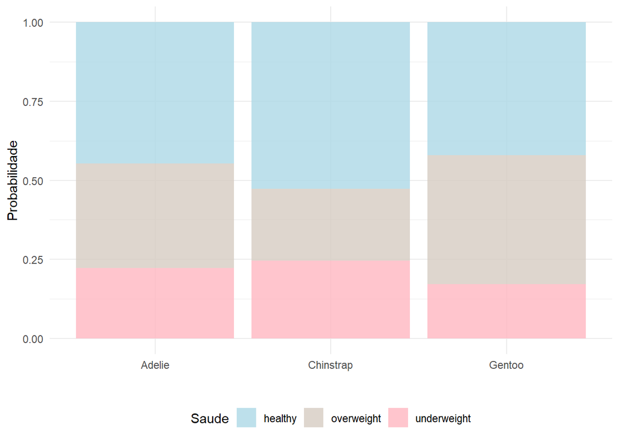

```r
# Plotando....
ggplot(preds11, aes(x = species, y = Probability, fill = health_metrics)) +
  geom_bar(stat = "identity", position = "stack",  alpha = 0.8) +
  scale_fill_manual(values = c("healthy" = "lightblue", "overweight" = "#d6ccc2", "underweight" = "lightpink")) +
  labs(y = "Probabilidade",
       x = "",
      fill = "Saude") +
  theme_minimal() +
  theme(legend.position = "bottom")
```

Extraíndo os coeficientes do modelo

```r
tmp <- summary(modelo1)
coefs <- tmp@coef3[, "Estimate"]
se <- tmp@coef3[, "Std. Error"]

results <- data.frame(Coef = coefs,
                      SE = se) #Savlando em um df


### Excluindo os interceptos (para melhor visualização)
results <- results[-c(1:3),]



### Calculando razão de chances & ICs a 95%
df_or <- results %>%
            mutate(OR = exp(Coef), #odds ratio
                   LCI = exp(Coef - (1.96 * SE)), #limite inferior do IC 95%
                   UCI = exp(Coef + (1.96 * SE)), #limite superior do IC 95%
                   Comparison = rownames(results)) #reavendo os níveis de comparação



### Formatando os dados para plotagem
df_or <- df_or %>%
          mutate(Species = gsub("^species", "", Comparison), #tirando 'species'
                 health_metrics = gsub(".*:", "", Comparison)) %>% #ficando apenas com os números
          mutate(Species = gsub(":[0-9]+$", "", Species), #tirando os números
                 health_metrics = ifelse(health_metrics == 1, "overweight", 'underweight')) #reclassificando os números de acordo com as categorias alimentares
```

Plotando o gráfico final

```
## `height` was translated to `width`.
```

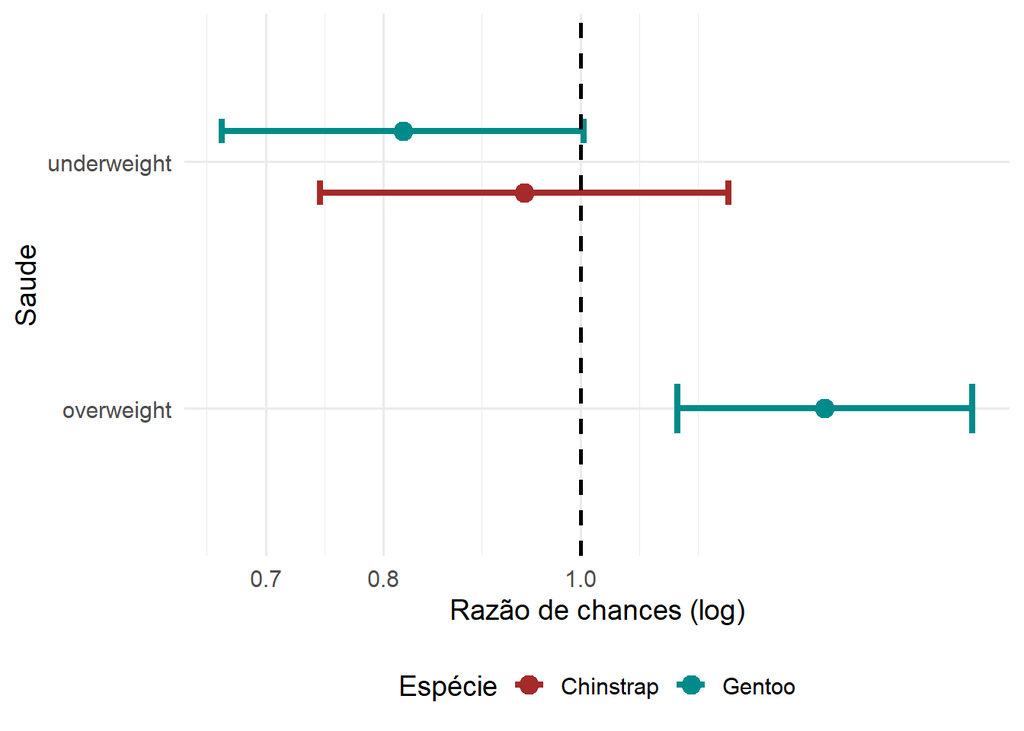

```r
ggplot(df_or, aes(y = health_metrics, x = OR, color = Species)) +
  geom_point(position = position_dodge(width = 0.5), size = 4) +
  geom_errorbarh(aes(xmin = LCI, xmax = UCI), height = 0.2, position = position_dodge(width = 0.5), size = 1.5) +
  geom_vline(xintercept = 1, linetype = "dashed", color = "black", size = 1) +
  scale_x_log10() + # Escala log para melhor visualização do OR
  scale_colour_manual(values = c("brown","darkcyan")) +
  labs(x = "Razão de chances (log)",
       y = "Saude",
       color = "Espécie") +
  theme_minimal(base_size = 14) +
  theme(legend.position = "bottom")
```

Modelo 2

```r
#Avaliando a relação entre a condição de saúde e os estágios de vida
modelo2 <- vglm(health_metrics ~ life_stage,
                family = multinomial(refLevel = 1),  # define a categoria de referência
                data = dados)

summary(modelo2)
```

```
##
## Call:
## vglm(formula = health_metrics ~ life_stage, family = multinomial(refLevel = 1),
##     data = dados)
##
## Coefficients:
##                      Estimate Std. Error z value Pr(>|z|)
## (Intercept):1         0.29044    0.06949   4.180 2.92e-05 ***
## (Intercept):2        -0.68216    0.09070  -7.521 5.44e-14 ***
## life_stagechick:1    -1.49564    0.11314 -13.219  < 2e-16 ***
## life_stagechick:2    -0.58635    0.12885  -4.551 5.34e-06 ***
## life_stagejuvenile:1 -0.50431    0.09113  -5.534 3.13e-08 ***
## life_stagejuvenile:2  0.14670    0.11150   1.316    0.188
## ---
## Signif. codes:  0 '***' 0.001 '**' 0.01 '*' 0.05 '.' 0.1 ' ' 1
##
## Names of linear predictors: log(mu[,2]/mu[,1]), log(mu[,3]/mu[,1])
##
## Residual deviance: 7002.468 on 6854 degrees of freedom
##
## Log-likelihood: -3501.234 on 6854 degrees of freedom
##
## Number of Fisher scoring iterations: 4
##
## No Hauck-Donner effect found in any of the estimates
##
##
## Reference group is level  1  of the response
```

```r
#Predições de probabilidade para cada estágio

dados_pred2 <- data.frame(life_stage = levels(dados$life_stage))

preds2 <- predict(modelo2,
                  newdata = dados_pred2,
                  type = "response") %>% data.frame()
```

Formatando os resultados para gerar o gráfico

```r
preds2$life_stage <- dados_pred2$life_stage

colnames(preds2) <- c("healthy", "overweight", "underweight","life_stage") #Renomeando as colunas da espécie, assumindo a mesma ordem do modelo

# Transformando o dado para o formato longo (necessário para o ggplot2)
preds21 <- preds2 %>%
                tidyr::pivot_longer(cols = c("healthy", "overweight", "underweight"),
                                    names_to = "health_metrics",
                                    values_to = "Probability")
```

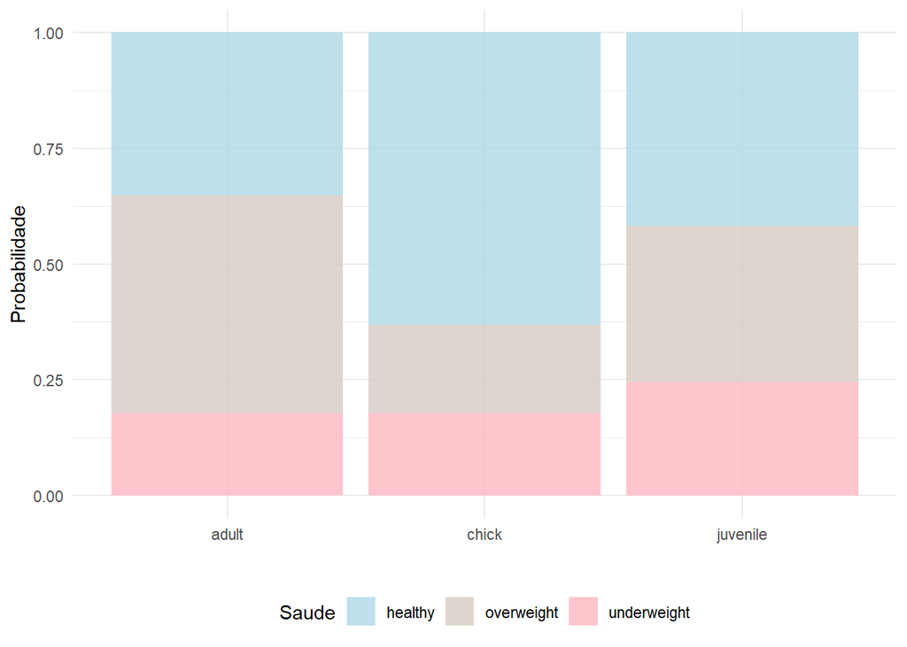

```r
# Plotando....
ggplot(preds21, aes(x = life_stage, y = Probability, fill = health_metrics)) +
  geom_bar(stat = "identity", position = "stack",  alpha = 0.8) +
  scale_fill_manual(values = c("healthy" = "lightblue", "overweight" = "#d6ccc2", "underweight" = "lightpink")) +
  labs(y = "Probabilidade",
       x = "",
      fill = "Saude") +
  theme_minimal() +
  theme(legend.position = "bottom")
```

Extraíndo os coeficientes do modelo

```r
tmp <- summary(modelo2)
coefs <- tmp@coef3[, "Estimate"]
se <- tmp@coef3[, "Std. Error"]

results <- data.frame(Coef = coefs,
                      SE = se) #Savlando em um df


### Excluindo os interceptos (para melhor visualização)
results <- results[-c(1:3),]



### Calculando razão de chances & ICs a 95%
df_or <- results %>%
            mutate(OR = exp(Coef), #odds ratio
                   LCI = exp(Coef - (1.96 * SE)), #limite inferior do IC 95%
                   UCI = exp(Coef + (1.96 * SE)), #limite superior do IC 95%
                   Comparison = rownames(results)) #reavendo os níveis de comparação



### Formatando os dados para plotagem
df_or <- df_or %>%
          mutate(life_stage = gsub("^life_stage", "", Comparison), #tirando 'species'
                 health_metrics = gsub(".*:", "", Comparison)) %>% #ficando apenas com os números
          mutate(life_stage = gsub(":[0-9]+$", "", life_stage), #tirando os números
                 health_metrics = ifelse(health_metrics == 1, "overweight", 'underweight')) #reclassificando os números de acordo com as categorias alimentares
```

Plotando o gráfico final

```
## `height` was translated to `width`.
```

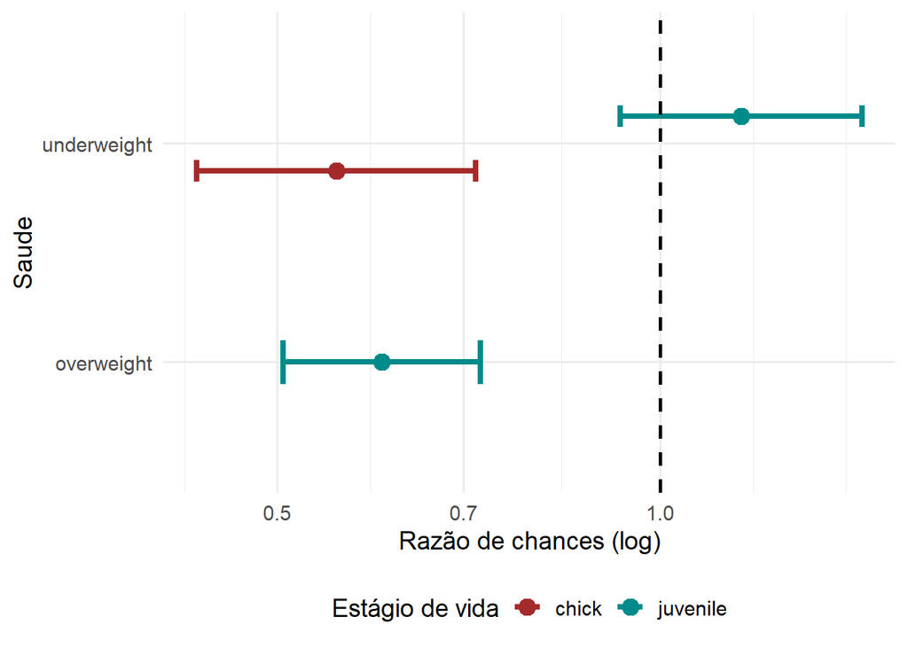

```r
ggplot(df_or, aes(y = health_metrics, x = OR, color = life_stage)) +
  geom_point(position = position_dodge(width = 0.5), size = 4) +
  geom_errorbarh(aes(xmin = LCI, xmax = UCI), height = 0.2, position = position_dodge(width = 0.5), size = 1.5) +
  geom_vline(xintercept = 1, linetype = "dashed", color = "black", size = 1) +
  scale_x_log10() + # Escala log para melhor visualização do OR
  scale_colour_manual(values = c("brown","darkcyan")) +
  labs(x = "Razão de chances (log)",
       y = "Saude",
       color = "Estágio de vida") +
  theme_minimal(base_size = 14) +
  theme(legend.position = "bottom")
```

A partir do gráfico e das análises, podemos concluir que filhotes apresentaram menor chance de estarem abaixo do peso em comparação com adultos (OR ≈ 0.6, IC 95% ≈ 0.45–0.75). Juvenis apresentaram menor chance de estarem acima do peso (“overweight”) do que adultos (OR ≈ 0.65, IC 95% ≈ 0.5–0.8).

Modelo 3

```r
#Avaliando a relação entre a condição de saúde e o sexo
modelo3 <- vglm(health_metrics ~ sex,
                family = multinomial(refLevel = 1),  # define a categoria de referência
                data = dados)

summary(modelo3)
```

```
##
## Call:
## vglm(formula = health_metrics ~ sex, family = multinomial(refLevel = 1),
##     data = dados)
##
## Coefficients:
##               Estimate Std. Error z value Pr(>|z|)
## (Intercept):1 -0.36624    0.05441  -6.731 1.68e-11 ***
## (Intercept):2 -0.91933    0.06520 -14.099  < 2e-16 ***
## sexmale:1      0.16863    0.07759   2.173  0.02975 *
## sexmale:2      0.28380    0.09075   3.127  0.00176 **
## ---
## Signif. codes:  0 '***' 0.001 '**' 0.01 '*' 0.05 '.' 0.1 ' ' 1
##
## Names of linear predictors: log(mu[,2]/mu[,1]), log(mu[,3]/mu[,1])
##
## Residual deviance: 7207.682 on 6856 degrees of freedom
##
## Log-likelihood: -3603.841 on 6856 degrees of freedom
##
## Number of Fisher scoring iterations: 4
##
## No Hauck-Donner effect found in any of the estimates
##
##
## Reference group is level  1  of the response
```

```r
#Predições de probabilidade para cada sexo

dados_pred3 <- data.frame(sex = levels(dados$sex))

preds3 <- predict(modelo3,
                  newdata = dados_pred3,
                  type = "response") %>% data.frame()
```

Formatar os resultados para gerar o gráfico

```r
preds3$sex <- dados_pred3$sex

colnames(preds3) <- c("healthy", "overweight", "underweight","sex") #Renomeando as colunas da espécie, assumindo a mesma ordem do modelo

### Transformar dado para o formato longo (necessário para o ggplot2)
preds31 <- preds3 %>%
                tidyr::pivot_longer(cols = c("healthy", "overweight", "underweight"),
                                    names_to = "health_metrics",
                                    values_to = "Probability")
```

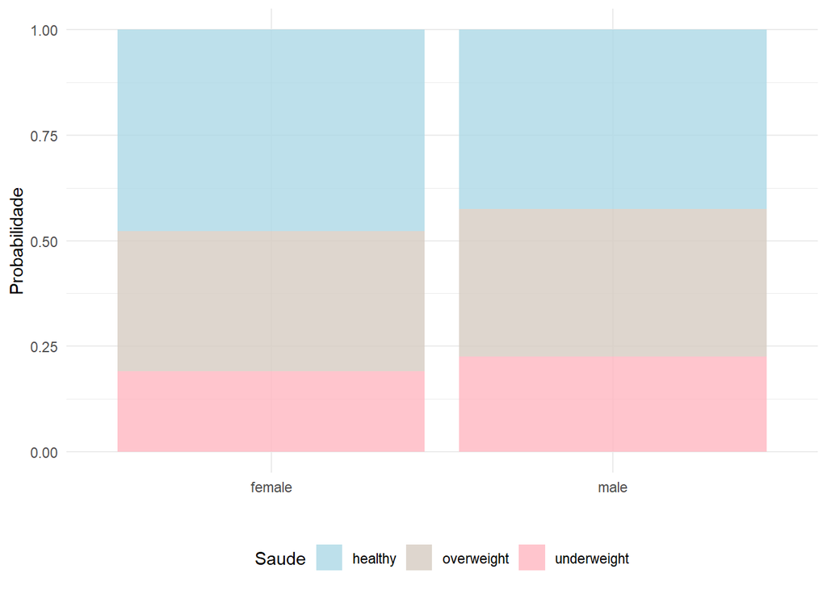

```r
### Plotando....
ggplot(preds31, aes(x = sex, y = Probability, fill = health_metrics)) +
  geom_bar(stat = "identity", position = "stack",  alpha = 0.8) +
  scale_fill_manual(values = c("healthy" = "lightblue", "overweight" = "#d6ccc2", "underweight" = "lightpink")) +
  labs(y = "Probabilidade",
       x = "",
      fill = "Saude") +
  theme_minimal() +
  theme(legend.position = "bottom")
```

Extraíndo os coeficientes do modelo

```r
tmp <- summary(modelo3)
coefs <- tmp@coef3[, "Estimate"]
se <- tmp@coef3[, "Std. Error"]

results <- data.frame(Coef = coefs,
                      SE = se) #Savlando em um df


### Excluindo os interceptos (para melhor visualização)
results <- results[-c(1:3),]



### Calculando razão de chances & ICs a 95%
df_or <- results %>%
            mutate(OR = exp(Coef), #odds ratio
                   LCI = exp(Coef - (1.96 * SE)), #limite inferior do IC 95%
                   UCI = exp(Coef + (1.96 * SE)), #limite superior do IC 95%
                   Comparison = rownames(results)) #reavendo os níveis de comparação



### Formatando os dados para plotagem
df_or <- df_or %>%
          mutate(sex = gsub("^life_stage", "", Comparison), #tirando 'species'
                 health_metrics = gsub(".*:", "", Comparison)) %>% #ficando apenas com os números
          mutate(sex = gsub(":[0-9]+$", "", sex), #tirando os números
                 health_metrics = ifelse(health_metrics == 1, "overweight", 'underweight')) #reclassificando os números de acordo com as categorias alimentares
```

Plotando o gráfico final

```
## `height` was translated to `width`.
```

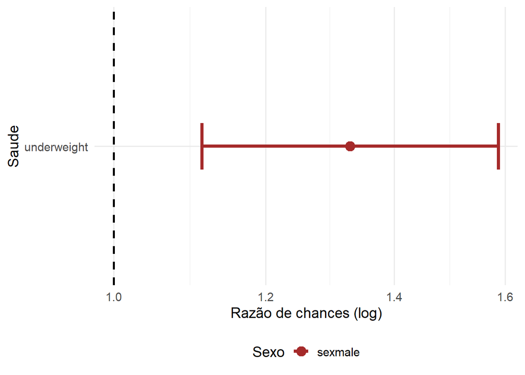

```r
ggplot(df_or, aes(y = health_metrics, x = OR, color = sex)) +
  geom_point(position = position_dodge(width = 0.5), size = 4) +
  geom_errorbarh(aes(xmin = LCI, xmax = UCI), height = 0.2, position = position_dodge(width = 0.5), size = 1.5) +
  geom_vline(xintercept = 1, linetype = "dashed", color = "black", size = 1) +
  scale_x_log10() + # Escala log para melhor visualização do OR
  scale_colour_manual(values = c("brown","darkcyan")) +
  labs(x = "Razão de chances (log)",
       y = "Saude",
       color = "Sexo") +
  theme_minimal(base_size = 14) +
  theme(legend.position = "bottom")
```

A partir do gráfico e das análises, podemos concluir que machos apresentaram uma chance significativamente maior de serem classificados como abaixo do peso (“underweight”) em comparação com fêmeas(OR ≈ 1.3, IC 95% ≈ 1.05–1.6).

Por fim, podemos concluir que as hipóteses foram corroboradas, havendo sim diferença da condição de saúde dos pinguins com relação à espécie, ao estágio de vida e ao sexo.